# Investigating Data - Covid Wider Impacts

Looking at wider covid impacts data weekly variability - related to 2018/19 baseline

revised version - now extracting all Scotland more easily.

```r
library("tidyverse")
library("janitor")
library("lubridate")
library("skimr")
library("infer")
```

#read in healthboard codes

```r
hb_codes <- read_csv(here::here("lookup_tables/health_board_codes.csv"))
hb_codes <- clean_names(hb_codes)
```

#load in datafiles

```r
weekly_admissions_spec <- read_csv("Covid admissions by health board and speciality.csv")
weekly_admissions_spec <- clean_names(weekly_admissions_spec)

weekly_admissions_dep <- read_csv("Covid admissions by health board and deprivation.csv")
weekly_admissions_dep <- clean_names(weekly_admissions_dep)

weekly_admissions_demog <- read_csv("Covid admissions by health board, age and sex.csv")
weekly_admissions_demog <- clean_names(weekly_admissions_demog)
```

data cleaning note probably more cleaning needed before we finalise I changed the spelling but it turns out both spellings are correct!

```r
weekly_admissions_spec <- weekly_admissions_spec %>%
  rename("speciality"= "specialty") %>%
  rename("speciality_qf"= "specialty_qf")
```

# merge hbnames into datafiles

```r
weekly_admissions_spec <- left_join(weekly_admissions_spec,hb_codes)
weekly_admissions_demog <- left_join(weekly_admissions_demog,hb_codes)
weekly_admissions_dep <- left_join(weekly_admissions_dep,hb_codes)
```

#do the analysis needed for identifying winter and ‘crisis’

```r
weekly_admissions_spec %>%
  distinct(hb_name)
```

| hb_name |
| --- |
| NHS Ayrshire and Arran |
| NHS Borders |
| NHS Dumfries and Galloway |
| NHS Forth Valley |
| NHS Grampian |
| NHS Highland |
| NHS Lothian |
| NHS Orkney |
| NHS Shetland |
| NHS Western Isles |

[output cut: 6 more lines]

```r
skim(weekly_admissions_spec)
```

```
── Data Summary ────────────────────────
                           Values
Name                       weekly_admissions_spec
Number of rows             55233
Number of columns          15
_______________________
Column type frequency:
  character                8
  numeric                  7
________________________
Group variables            None
```

|  | skim_variable | n_missing | complete_rate | min | max | empty | n_unique | whitespace |
| --- | --- | --- | --- | --- | --- | --- | --- | --- |
| 1 | hb | 1695 | 0.9693118 | 9 | 9 | 0 | 15 | 0 |
| 2 | hbqf | 49452 | 0.1046657 | 1 | 1 | 0 | 1 | 0 |
| 3 | admission_type | 0 | 1.0000000 | 3 | 9 | 0 | 3 | 0 |
| 4 | admission_type_qf | 34544 | 0.3745768 | 1 | 1 | 0 | 1 | 0 |
| 5 | speciality | 882 | 0.9840313 | 3 | 35 | 0 | 12 | 0 |
| 6 | speciality_qf | 48154 | 0.1281661 | 1 | 1 | 0 | 1 | 0 |
| 7 | hb_name | 1695 | 0.9693118 | 8 | 29 | 0 | 15 | 0 |
| 8 | country | 1695 | 0.9693118 | 9 | 9 | 0 | 1 | 0 |

|  | skim_variable | n_missing | complete_rate | mean | sd | p0 | p25 | p50 | p75 | p100 | hist |
| --- | --- | --- | --- | --- | --- | --- | --- | --- | --- | --- | --- |
| 1 | id | 0 | 1.0000000 | 2.761700e+04 | 15944.5380 | 1.0 | 13809.0 | 27617.0 | 41425 | 55233.0 | ▇▇▇▇▇ |
| 2 | week_ending | 0 | 1.0000000 | 2.021040e+07 | 8084.3766 | 20200105.0 | 20200927.0 | 20210620.0 | 20220313 | 20221127.0 | ▇▁▇▁▇ |
| 3 | number_admissions | 0 | 1.0000000 | 3.894794e+02 | 1205.6130 | 5.0 | 21.0 | 70.0 | 264 | 15726.0 | ▇▁▁▁▁ |
| 4 | average20182019 | 0 | 1.0000000 | 4.441000e+02 | 1350.2675 | 0.0 | 25.5 | 84.0 | 305 | 16501.5 | ▇▁▁▁▁ |
| 5 | percent_variation | 0 | 1.0000000 | 5.841111e+00 | 272.8359 | -95.9 | -28.6 | -11.8 | 4 | 8000.0 | ▇▁▁▁▁ |
| 6 | hb_date_enacted | 7476 | 0.8646461 | 2.015643e+07 | 21800.8283 | 20140401.0 | 20140401.0 | 20140401.0 | 20180202 | 20190401.0 | ▇▁▁▂▂ |
| 7 | hb_date_archived | 55233 | 0.0000000 | NaN | NA | NA | NA | NA | NA | NA |  |

```r
weekly_admissions_demog <- weekly_admissions_demog %>%
  mutate(year = as.integer(str_sub(week_ending,1,4))) %>%
  mutate(month = as.integer(str_sub(week_ending,5,6))) %>%
  mutate(day = as.integer(str_sub(week_ending,7,8))) %>%
  mutate(wdate = ymd(week_ending)) %>%
  # identify "All Scotland" data
  mutate(hb_name = ifelse(hb=="S92000003","All Scotland",hb_name)) %>%
  mutate(hb_name = ifelse(is.na(hb_name),"NHS Region Unknown",hb_name)) %>%
  mutate(iswinter = ifelse(month %in% c(4,5,6,7,8,9),FALSE,TRUE)) %>%
  mutate(above_thresh = ifelse(percent_variation>0,7,0))
```

```r
weekly_admissions_spec <- weekly_admissions_spec %>%
  mutate(year = as.integer(str_sub(week_ending,1,4))) %>%
  mutate(month = as.integer(str_sub(week_ending,5,6))) %>%
  mutate(day = as.integer(str_sub(week_ending,7,8))) %>%
  mutate(wdate = ymd(week_ending)) %>%
  # identify "All Scotland" data
  mutate(hb_name = ifelse(hb=="S92000003","All Scotland",hb_name)) %>%
  mutate(hb_name = ifelse(is.na(hb_name),"NHS Region Unknown",hb_name)) %>%
  mutate(iswinter = ifelse(month %in% c(4,5,6,7,8,9),FALSE,TRUE)) %>%
  mutate(above_thresh = ifelse(percent_variation>0,7,0))
```

```r
monthly_admissions_spec <- weekly_admissions_spec

monthly_admissions_spec <- monthly_admissions_spec %>%
  group_by(hb, admission_type, speciality, year, month) %>%
  summarise(monthly_admissions = 4*mean(number_admissions, na.rm = TRUE)) %>%
  mutate(mdate = as.Date(make_datetime(year, month, 15))) %>%
  ungroup()
```

#merge hbnames into datafiles

```r
monthly_admissions_spec <- left_join(monthly_admissions_spec,hb_codes)
#monthly_admissions_demog <- left_join(monthly_admissions_demog,hb_codes)
#monthly_admissions_dep <- left_join(monthly_admissions_dep,hb_codes)
```

```r
monthly_admissions_spec <- monthly_admissions_spec %>%
  mutate(hb_name = ifelse(is.na(hb_name),"NHS Region Unknown",hb_name)) %>%
  mutate(iswinter = ifelse(month %in% c(4,5,6,7,8,9),FALSE,TRUE))
```

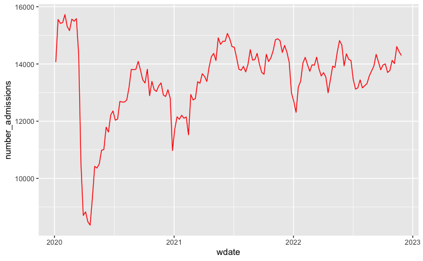

```r
weekly_admissions_spec %>%
  filter(speciality == "All") %>%
  filter(admission_type == "All") %>%
  filter(hb_name =="All Scotland") %>%
ggplot() +
aes(x=wdate, y = number_admissions) +
geom_line(colour='red')
```

check results

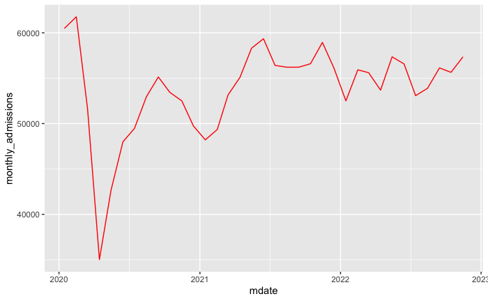

```r
monthly_admissions_spec%>%
  filter(speciality == "All") %>%
  filter(admission_type == "All") %>%
  filter(hb_name =="All Scotland") %>%
ggplot() +
aes(x=mdate, y = monthly_admissions) +
geom_line(colour='red')
```

```r
monthly_admissions_spec %>%
filter(year == 2021) %>%
filter(month==8) %>%
  filter(speciality == "All") %>%
  filter(admission_type == "All") %>%
  filter(hb_name =="All Scotland")
```

| hb | admission_type | speciality | year | month | monthly_admissions | mdate | hb_name | hb_date_enacted | hb_date_archived | country | iswinter |
| --- | --- | --- | --- | --- | --- | --- | --- | --- | --- | --- | --- |
| S92000003 | All | All | 2021 | 8 | 56209.6 | 2021-08-15 | All Scotland | NA | NA | S92000003 | FALSE |

```r
library(slider)

data_rolling <- weekly_admissions_spec %>%
  filter(wdate > as.Date("2020-05-01")) %>%
  filter(speciality == "All") %>%
  filter(admission_type == "All") %>%
  filter(hb_name =="All Scotland") %>%
  mutate(
    moving_avg = slide_dbl(
      .x = number_admissions,
      .f = ~ mean(., na.rm = TRUE),
      .before = 12,
      .after = 12,
      .complete = FALSE
    )
  )
data_rolling
```

| id | week_ending | hb | hbqf | admission_type | admission_type_qf | speciality | speciality_qf | number_admissions | average20182019 | percent_variation | hb_name | hb_date_enacted | hb_date_archived | country | year | month | day | wdate | iswinter | above_thresh | moving_avg |
| --- | --- | --- | --- | --- | --- | --- | --- | --- | --- | --- | --- | --- | --- | --- | --- | --- | --- | --- | --- | --- | --- |
| 2416 | 20200503 | S92000003 | d | All | d | All | d | 10422 | 15608.5 | -33.2 | All Scotland | NA | NA | S92000003 | 2020 | 5 | 3 | 2020-05-03 | FALSE | 0 | 11595.69 |
| 2548 | 20200510 | S92000003 | d | All | d | All | d | 10363 | 15113.5 | -31.4 | All Scotland | NA | NA | S92000003 | 2020 | 5 | 10 | 2020-05-10 | FALSE | 0 | 11672.43 |
| 2682 | 20200517 | S92000003 | d | All | d | All | d | 10510 | 15783.0 | -33.4 | All Scotland | NA | NA | S92000003 | 2020 | 5 | 17 | 2020-05-17 | FALSE | 0 | 11743.47 |
| 2815 | 20200524 | S92000003 | d | All | d | All | d | 10987 | 15633.5 | -29.7 | All Scotland | NA | NA | S92000003 | 2020 | 5 | 24 | 2020-05-24 | FALSE | 0 | 11833.00 |
| 2953 | 20200531 | S92000003 | d | All | d | All | d | 11008 | 15458.5 | -28.8 | All Scotland | NA | NA | S92000003 | 2020 | 5 | 31 | 2020-05-31 | FALSE | 0 | 11949.24 |
| 3088 | 20200607 | S92000003 | d | All | d | All | d | 11792 | 15490.5 | -23.9 | All Scotland | NA | NA | S92000003 | 2020 | 6 | 7 | 2020-06-07 | FALSE | 0 | 12052.00 |
| 3221 | 20200614 | S92000003 | d | All | d | All | d | 11619 | 15507.5 | -25.1 | All Scotland | NA | NA | S92000003 | 2020 | 6 | 14 | 2020-06-14 | FALSE | 0 | 12144.63 |
| 3357 | 20200621 | S92000003 | d | All | d | All | d | 12217 | 15556.0 | -21.5 | All Scotland | NA | NA | S92000003 | 2020 | 6 | 21 | 2020-06-21 | FALSE | 0 | 12241.95 |
| 3493 | 20200628 | S92000003 | d | All | d | All | d | 12358 | 15455.0 | -20.0 | All Scotland | NA | NA | S92000003 | 2020 | 6 | 28 | 2020-06-28 | FALSE | 0 | 12315.57 |
| 3633 | 20200705 | S92000003 | d | All | d | All | d | 12034 | 15081.5 | -20.2 | All Scotland | NA | NA | S92000003 | 2020 | 7 | 5 | 2020-07-05 | FALSE | 0 | 12366.86 |

[output cut: 125 more lines]

#calculate difference to create mvar

```r
data_rolling <- data_rolling %>%
  mutate(mvar = number_admissions- moving_avg)
```

# plot - check the smoother makes sense and tweak values if they dont

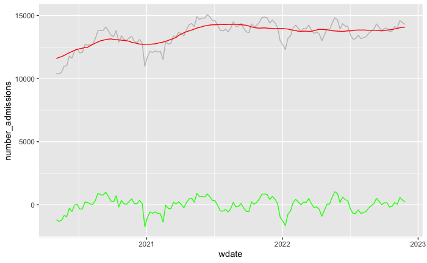

```r
ggplot(data_rolling)+
  geom_line(aes(x = wdate, y = number_admissions), colour = "gray") +
  geom_line(aes(x = wdate, y = moving_avg), colour = "red") +
  geom_line(aes(x = wdate, y = mvar), colour = "green")
```

#now create a boxplot

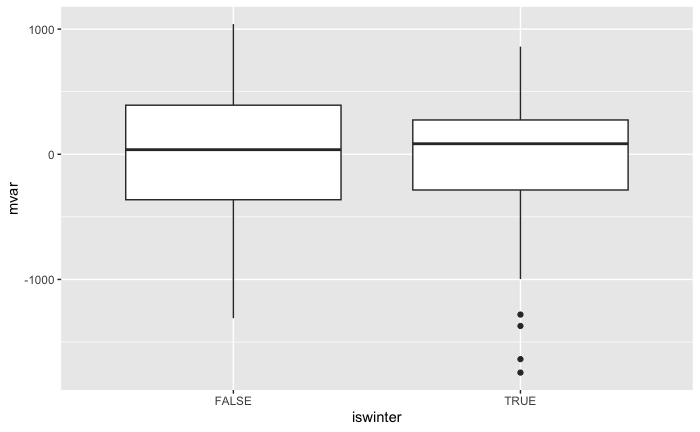

```r
data_rolling %>%
  ggplot() +
  aes(x=iswinter, y=mvar) +
  geom_boxplot()
```

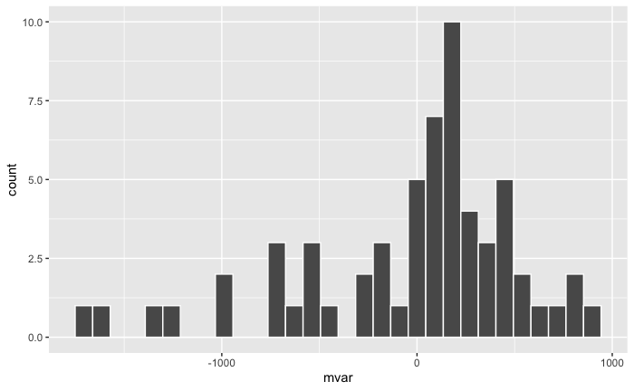

```r
data_rolling %>%
  filter(iswinter) %>%
  ggplot() +
  aes(x = mvar) +
  geom_histogram(col = "white")
```

```r
seasonal_avg <- data_rolling %>%
  group_by(iswinter) %>%
  summarise(mean= mean(mvar, na.rm=TRUE))
seasonal_avg
```

| iswinter | mean |
| --- | --- |
| FALSE | 6.04220 |
| TRUE | -38.32062 |

```r
weekly_admissions_dep <- weekly_admissions_dep %>%
  mutate(year = as.integer(str_sub(week_ending,1,4))) %>%
  mutate(month = as.integer(str_sub(week_ending,5,6))) %>%
  mutate(day = as.integer(str_sub(week_ending,7,8))) %>%
  mutate(wdate = ymd(week_ending)) %>%
  # identify "All Scotland" data
  mutate(hb_name = ifelse(hb=="S92000003","All Scotland",hb_name)) %>%
  mutate(hb_name = ifelse(is.na(hb_name),"NHS Region Unknown",hb_name)) %>%
  mutate(iswinter = ifelse(month %in% c(4,5,6,7,8,9),FALSE,TRUE)) %>%
  mutate(above_thresh = ifelse(percent_variation>0,7,0))
```

take a look at what is in each dataset

```r
weekly_admissions_spec %>%
  distinct(hb_name)
```

| hb_name |
| --- |
| NHS Ayrshire and Arran |
| NHS Borders |
| NHS Dumfries and Galloway |
| NHS Forth Valley |
| NHS Grampian |
| NHS Highland |
| NHS Lothian |
| NHS Orkney |
| NHS Shetland |
| NHS Western Isles |

[output cut: 6 more lines]

14 health boards plus ‘all scotland’ and an NA - need to work out what to do with this

```r
weekly_admissions_spec %>%
  distinct(admission_type)
```

| admission_type |
| --- |
| All |
| Emergency |
| Planned |

Data neatly divided into emergency and planned

```r
weekly_admissions_spec %>%
  distinct(speciality)
```

| speciality |
| --- |
| Accident & Emergency |
| All |
| Cardiology |
| Medical (excl. Cardiology & Cancer) |
| Medical (incl. Cardiology & Cancer) |
| Paediatrics (medical & surgical) |
| Paediatrics (medical) |
| Surgery |
| Community |
| Gynaecology |

[output cut: 3 more lines]

note that some groupings are also combined. need to take a closer look at what these mean.

```r
weekly_admissions_demog %>%
  distinct(age_group)
```

| age_group |
| --- |
| Under 5 |
| 5 - 14 |
| 15 - 44 |
| 45 - 64 |
| 65 - 74 |
| 75 - 84 |
| 85 and over |
| All ages |

7 age groups and “all ages”

```r
weekly_admissions_demog %>%
  distinct(sex)
```

| sex |
| --- |
| All |
| Female |
| Male |

just male - female and all

```r
weekly_admissions_dep %>%
  distinct(simd_quintile)
```

| simd_quintile |
| --- |
| 1 |
| 2 |
| 3 |
| 4 |
| 5 |

note there is no ‘all’ category in this dataset

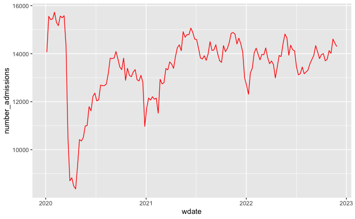

```r
weekly_admissions_spec %>%
  filter(speciality == "All") %>%
  filter(admission_type == "All") %>%
  filter(hb_name =="All Scotland") %>%
ggplot() +
aes(x=wdate, y = number_admissions) +
geom_line(colour='red')
```

same graph as above!

weekly hospital admissions hover around 14000 per week expect 168,000 per quarter?

pre=pandemic hospital admissions hovered around 15500 per week expect 186,000 per quarter

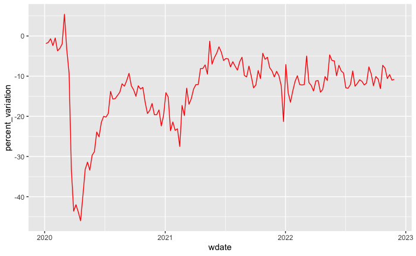

```r
weekly_admissions_spec %>%
  filter(speciality == "All") %>%
  filter(admission_type == "All") %>%
  filter(hb_name =="All Scotland") %>%
ggplot() +
aes(x=wdate, y = percent_variation) +
geom_line(colour='red')
```

Overall(all specialities, all admissions, all healthboards) admissions are only at 90% of pre-pandemic levels

quick look at demographics

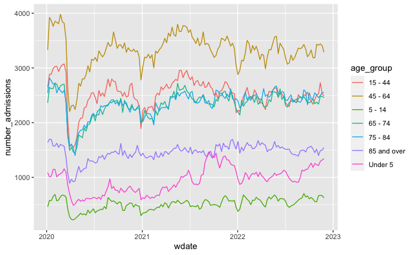

```r
weekly_admissions_demog %>%
  filter(sex == "All") %>%
  filter(age_group != "All ages") %>%
  filter(hb_name =="All Scotland") %>%
  filter(admission_type == "All") %>%
ggplot() +
aes(x=wdate, y = number_admissions, color = age_group) +
geom_line() #+
```

```r
#scale_colour_brewer(palette = "Set2")
```

age plot shows some variation between age groups.

quick look at sex differences

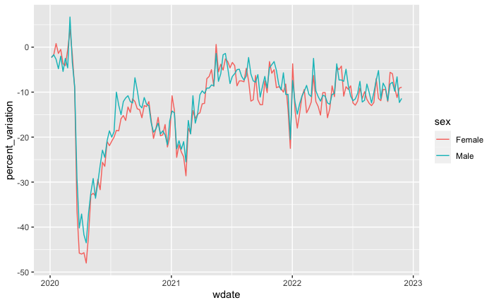

```r
weekly_admissions_demog %>%
  filter(sex != "All") %>%
  filter(age_group == "All ages") %>%
  filter(hb_name =="All Scotland") %>%
  filter(admission_type == "All") %>%
ggplot() +
aes(x=wdate, y = percent_variation, color = sex) +
geom_line() #+
```

```r
#scale_colour_brewer(palette = "Set2")
```

quick look at index of deprivation. 1 is most deprived and 5 is least deprived

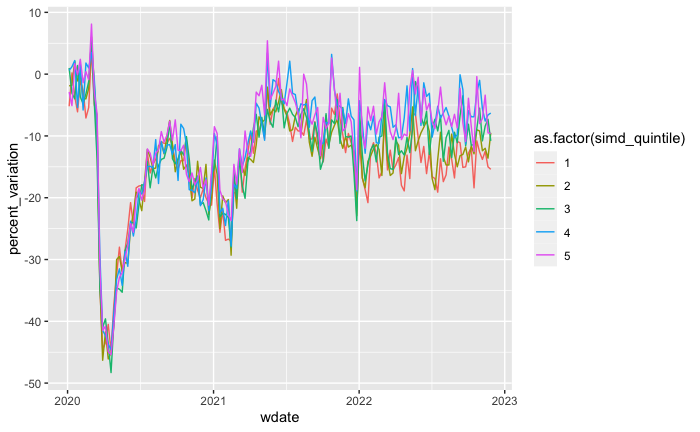

```r
weekly_admissions_dep %>%
  filter(admission_type == "All") %>%
  filter(hb_name =="All Scotland") %>%
ggplot() +
aes(x=wdate, y = percent_variation, color = as.factor(simd_quintile)) +
geom_line()
```

something happening in 2022 - why is there divergence between 1 and 5?

look at admissions type

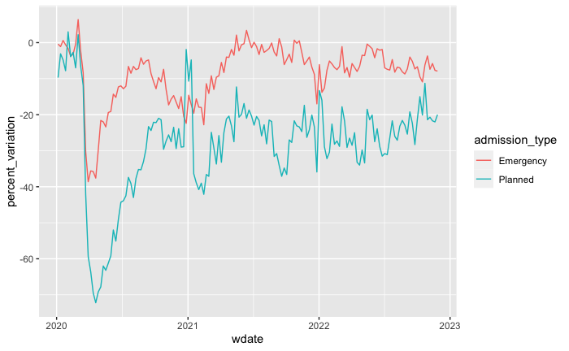

```r
weekly_admissions_spec %>%
  filter(admission_type != "All") %>%
  filter(speciality=="All") %>%
  filter(hb_name =="All Scotland") %>%
ggplot() +
aes(x=wdate, y = percent_variation, colour = admission_type) +
geom_line()
```

need to check what the ‘spike’ in planned at end of 2021 is related to

quick look at specialities

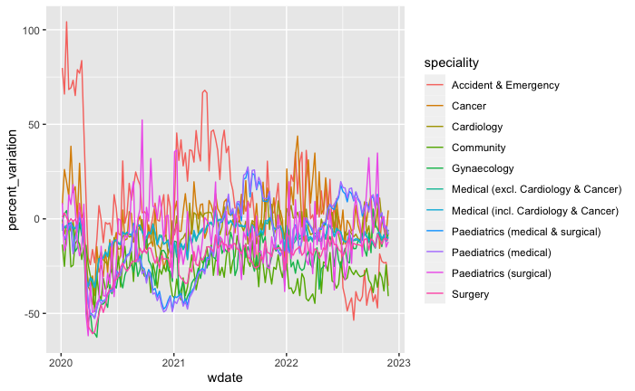

```r
weekly_admissions_spec %>%
  filter(admission_type == "All") %>%
  filter(speciality !="All") %>%
  filter(hb_name =="All Scotland") %>%
ggplot() +
aes(x=wdate, y = percent_variation, colour=speciality) +
geom_line()
```

take a closer look at paediatrics

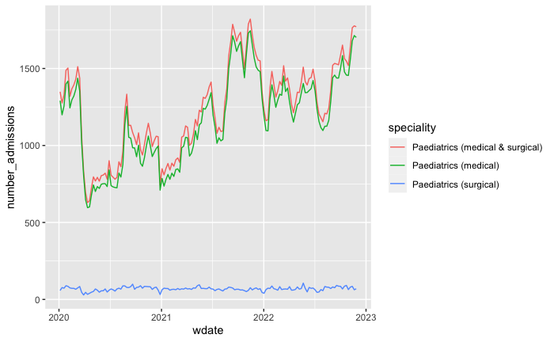

```r
weekly_admissions_spec %>%
  filter(admission_type == "All") %>%
  filter(speciality !="All") %>%
  filter(str_detect(speciality,"Paed")) %>%
  filter(hb_name =="All Scotland") %>%
ggplot() +
aes(x=wdate, y = number_admissions, colour=speciality) +
geom_line()
```

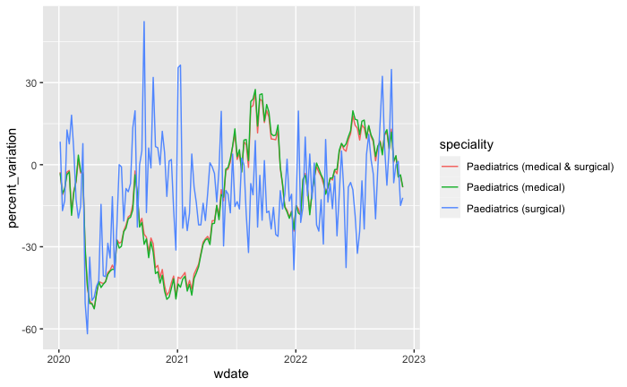

```r
weekly_admissions_spec %>%
  filter(admission_type == "All") %>%
  filter(speciality !="All") %>%
  filter(str_detect(speciality,"Paed")) %>%
  filter(hb_name =="All Scotland") %>%
ggplot() +
aes(x=wdate, y = percent_variation, colour=speciality) +
geom_line()
```

take a closer look at medical

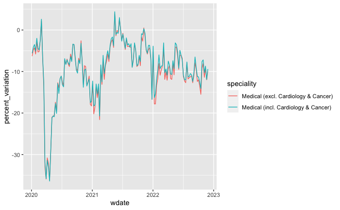

```r
weekly_admissions_spec %>%
  filter(admission_type == "All") %>%
  filter(speciality !="All") %>%
  filter(str_detect(speciality,"Medical")) %>%
  filter(hb_name =="All Scotland") %>%
ggplot() +
aes(x=wdate, y = percent_variation, colour=speciality) +
geom_line()
```

simpler plot of specialities

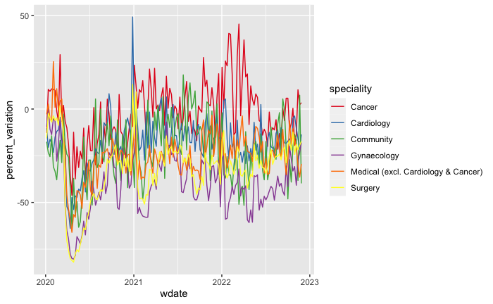

```r
weekly_admissions_spec %>%
  filter(admission_type == "Planned") %>%
  filter(speciality !="Medical (incl. Cardiology & Cancer)") %>%
  filter(!str_detect(speciality,"Paed")) %>%
  filter(speciality !="All") %>%
  filter(speciality !="Accident & Emergency") %>%
  filter(hb_name =="All Scotland") %>%
ggplot() +
aes(x=wdate, y = percent_variation, colour=speciality) +
geom_line() +
scale_colour_brewer(palette = "Set1")
```

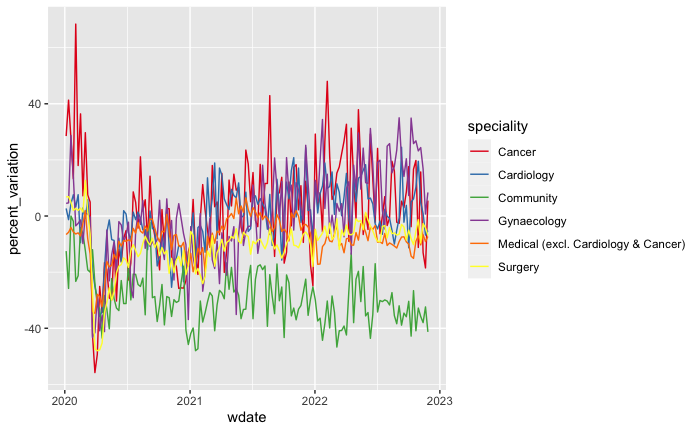

```r
weekly_admissions_spec %>%
  filter(admission_type == "Emergency") %>%
  filter(speciality !="Medical (incl. Cardiology & Cancer)") %>%
  filter(!str_detect(speciality,"Paed")) %>%
  filter(speciality !="All") %>%
  filter(speciality !="Accident & Emergency") %>%
  filter(hb_name =="All Scotland") %>%
ggplot() +
aes(x=wdate, y = percent_variation, colour=speciality) +
geom_line() +
scale_colour_brewer(palette = "Set1")
```

```r
weekly_admissions_spec %>%
  #filter(admission_type == "All") %>%
  #filter(speciality!="All") %>%
  #filter(hb_name =="NHS Region Unknown") %>%
  #group_by(speciality) %>%
  #need to take a good look at what these values are!
  filter(percent_variation>500)
```

| id | week_ending | hb | hbqf | admission_type | admission_type_qf | speciality | speciality_qf | number_admissions | average20182019 | percent_variation | hb_name | hb_date_enacted | hb_date_archived | country | year | month | day | wdate | iswinter | above_thresh |
| --- | --- | --- | --- | --- | --- | --- | --- | --- | --- | --- | --- | --- | --- | --- | --- | --- | --- | --- | --- | --- |
| 325 | 20200119 | S08000024 | NA | All | d | Accident & Emergency | NA | 263 | 27.5 | 856.4 | NHS Lothian | 20140401 | NA | S92000003 | 2020 | 1 | 19 | 2020-01-19 | TRUE | 7 |
| 3429 | 20200628 | S08000024 | NA | All | d | Community | NA | 5 | 0.0 | 8000.0 | NHS Lothian | 20140401 | NA | S92000003 | 2020 | 6 | 28 | 2020-06-28 | FALSE | 7 |
| 3507 | 20200628 | NA | NA | All | d | Gynaecology | NA | 5 | 0.0 | 8000.0 | NHS Region Unknown | NA | NA | NA | 2020 | 6 | 28 | 2020-06-28 | FALSE | 7 |
| 3570 | 20200705 | S08000024 | NA | All | d | Community | NA | 5 | 0.0 | 8000.0 | NHS Lothian | 20140401 | NA | S92000003 | 2020 | 7 | 5 | 2020-07-05 | FALSE | 7 |
| 3977 | 20200726 | S08000024 | NA | All | d | Community | NA | 8 | 0.0 | 8000.0 | NHS Lothian | 20140401 | NA | S92000003 | 2020 | 7 | 26 | 2020-07-26 | FALSE | 7 |
| 4118 | 20200802 | S08000024 | NA | All | d | Community | NA | 8 | 0.0 | 8000.0 | NHS Lothian | 20140401 | NA | S92000003 | 2020 | 8 | 2 | 2020-08-02 | FALSE | 7 |
| 4255 | 20200809 | S08000024 | NA | All | d | Community | NA | 9 | 0.0 | 8000.0 | NHS Lothian | 20140401 | NA | S92000003 | 2020 | 8 | 9 | 2020-08-09 | FALSE | 7 |
| 4333 | 20200809 | NA | NA | All | d | Gynaecology | NA | 5 | 0.0 | 8000.0 | NHS Region Unknown | NA | NA | NA | 2020 | 8 | 9 | 2020-08-09 | FALSE | 7 |
| 4396 | 20200816 | S08000024 | NA | All | d | Community | NA | 7 | 0.0 | 8000.0 | NHS Lothian | 20140401 | NA | S92000003 | 2020 | 8 | 16 | 2020-08-16 | FALSE | 7 |
| 4535 | 20200823 | S08000024 | NA | All | d | Community | NA | 6 | 0.0 | 8000.0 | NHS Lothian | 20140401 | NA | S92000003 | 2020 | 8 | 23 | 2020-08-23 | FALSE | 7 |

[output cut: 220 more lines]

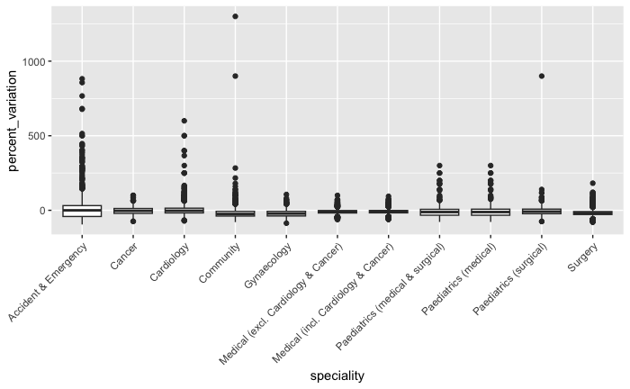

```r
weekly_admissions_spec %>%
  filter(admission_type == "All") %>%
  filter(speciality!="All") %>%
  group_by(speciality) %>%
  #need to take a good look at what these values are!
  filter(percent_variation<8000) %>%
  ggplot()+
  aes(x=speciality, y=percent_variation)+
  geom_boxplot()+
  theme(axis.text.x = element_text(angle = 45, hjust = 1))
```

some specialities have faced higher admission levels than others.

Now look by health boards

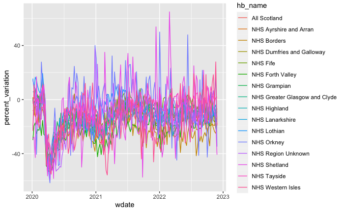

```r
weekly_admissions_spec %>%
  filter(admission_type == "All") %>%
  filter(speciality=="All") %>%
  group_by(hb_name) %>%
  ggplot()+
  aes(x=wdate, y=percent_variation, colour = hb_name)+
  geom_line()
```

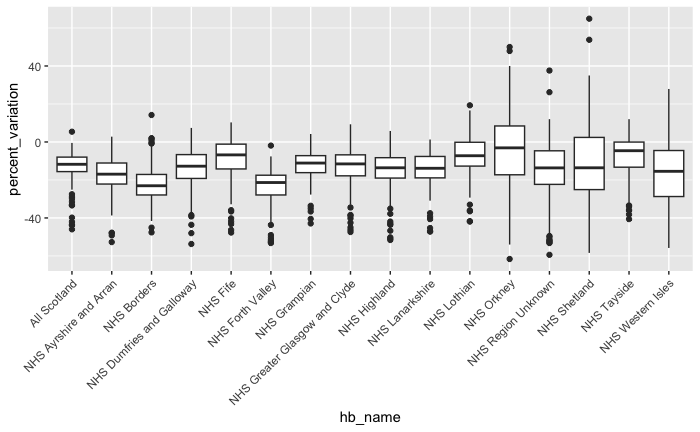

```r
weekly_admissions_spec %>%
  filter(admission_type == "All") %>%
  filter(speciality=="All") %>%
  group_by(hb_name) %>%
  ggplot()+
  aes(x=hb_name, y=percent_variation)+
  geom_boxplot()+
  theme(axis.text.x = element_text(angle = 45, hjust = 1))
```

for some health boards a significant number of admissions levels are above the levels seen in 2018-19. could we parhaps try and use this as an indicator?

Need to think more carefully about what the data in ‘region unknown’ means

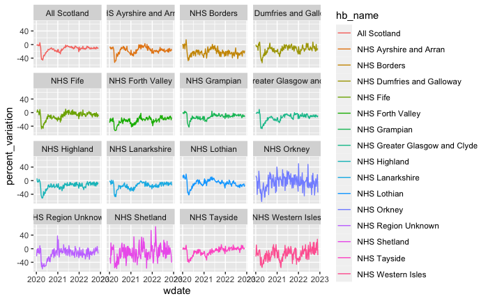

```r
weekly_admissions_spec %>%
  filter(admission_type == "All") %>%
  filter(speciality=="All") %>%
  ggplot() +
  aes(x=wdate, y=percent_variation, colour=hb_name) +
  geom_line()+
  facet_wrap(~hb_name)
```

How is NA calculated - still need to check??

```r
weekly_admissions_spec %>%
  filter(admission_type == "All") %>%
  filter(speciality == "All") %>%
  filter(hb_name != "All Scotland") %>%
  group_by(hb_name) %>%
  summarise(mean = mean(number_admissions)) %>%
  arrange(desc(mean))
```

| hb_name | mean |
| --- | --- |
| NHS Greater Glasgow and Clyde | 3521.78947 |
| NHS Lothian | 2052.30263 |
| NHS Lanarkshire | 1467.68421 |
| NHS Grampian | 1170.22368 |
| NHS Tayside | 1154.01974 |
| NHS Ayrshire and Arran | 931.50000 |
| NHS Fife | 849.23684 |
| NHS Forth Valley | 721.03947 |
| NHS Highland | 678.82237 |
| NHS Dumfries and Galloway | 367.09868 |

[output cut: 5 more lines]

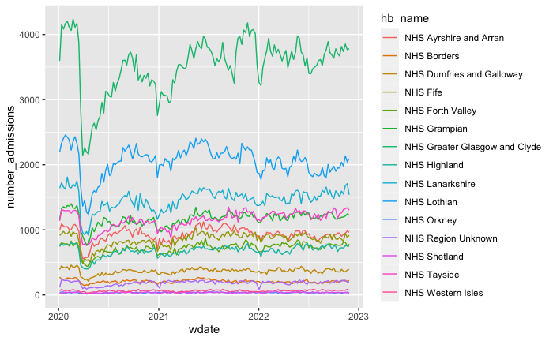

```r
weekly_admissions_spec %>%
  filter(admission_type == "All") %>%
  filter(speciality == "All") %>%
  filter(hb_name != "All Scotland") %>%
ggplot() +
aes(x=wdate, y = number_admissions, colour = hb_name) +
geom_line()
```

admission values shows all health boards - health boards vary massively in size and admission numbers but mostly same overall pattern.

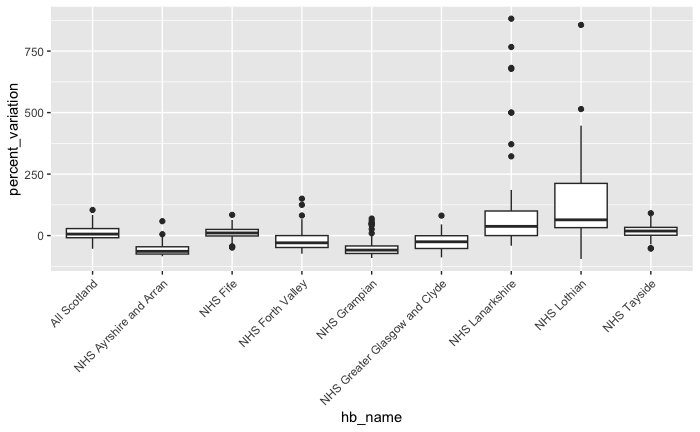

```r
weekly_admissions_spec %>%
  filter(admission_type == "All") %>%
  filter(speciality=="Accident & Emergency") %>%
  #take a good look at what these values are!
  filter(percent_variation<8000) %>%
  group_by(hb_name) %>%
  ggplot()+
  aes(x=hb_name, y=percent_variation)+
  geom_boxplot() +
  theme(axis.text.x = element_text(angle = 45, hjust = 1))
```

do only certain health boards have an A+E dept?

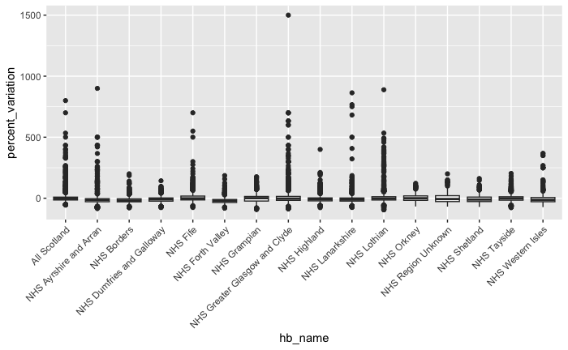

```r
weekly_admissions_spec %>%
  filter(admission_type == "Emergency") %>%
  #filter(speciality=="Accident & Emergency") %>%
  #take a good look at what these values are!
  filter(percent_variation<8000) %>%
  group_by(hb_name) %>%
  ggplot()+
  aes(x=hb_name, y=percent_variation)+
  geom_boxplot() +
  theme(axis.text.x = element_text(angle = 45, hjust = 1))
```

first attempt at a ‘crisis’ calculation

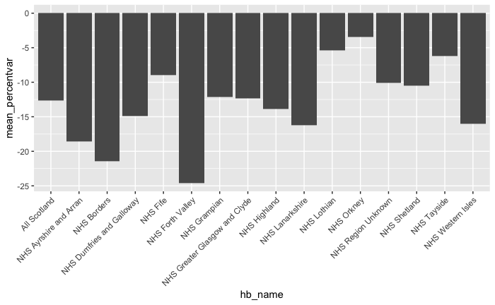

```r
weekly_admissions_spec %>%
  filter(admission_type == "All") %>%
  filter(speciality=="All") %>%
  #filter(admission_type =="Emergency") %>%
  #filter(speciality=="Accident & Emergency") %>%
  #filter(year == 2020) %>%
  filter(iswinter) %>%
  group_by(hb_name) %>%
  summarise(count_bad_days = sum(above_thresh),
            count_days = n()*7,
            pcnt_bad_days = 100*(sum(above_thresh)/(n()*7)),
            mean_percentvar =mean(percent_variation)) %>%
  ggplot() +
  aes(x=hb_name, y=mean_percentvar) +
  geom_col() +
  theme(axis.text.x = element_text(angle = 45, hjust = 1))
```

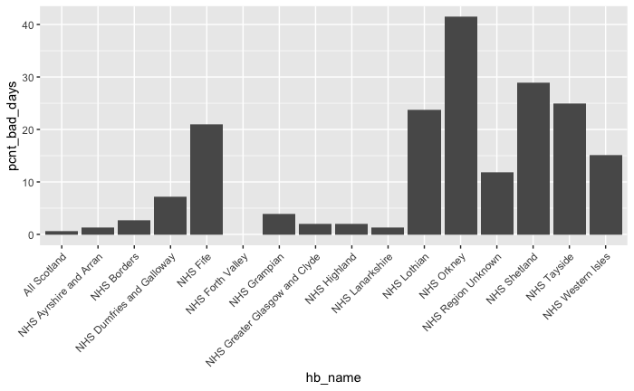

```r
weekly_admissions_spec %>%
  filter(speciality=="All") %>%
  filter(admission_type =="All") %>%
  #filter(year == 2021) %>%
  #filter(iswinter) %>%
  group_by(hb_name) %>%
  summarise(count_bad_days = sum(above_thresh),
            count_days = n()*7,
            pcnt_bad_days = 100*(sum(above_thresh)/(n()*7)),
            mean_percentvar =mean(percent_variation)) %>%
  ggplot() +
  aes(x=hb_name, y=pcnt_bad_days) +
  geom_col() +
  theme(axis.text.x = element_text(angle = 45, hjust = 1))
```

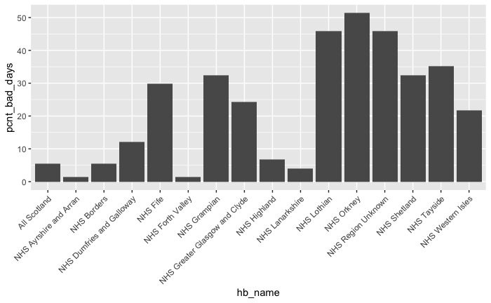

```r
weekly_admissions_spec %>%
  filter(speciality=="All") %>%
  filter(admission_type =="Emergency") %>%
  #filter(speciality=="Accident & Emergency") %>%
  #filter(year == 2020) %>%
  filter(iswinter) %>%
  group_by(hb_name) %>%
  summarise(count_bad_days = sum(above_thresh),
            count_days = n()*7,
            pcnt_bad_days = 100*(sum(above_thresh)/(n()*7)),
            mean_percentvar =mean(percent_variation)) %>%
  ggplot() +
  aes(x=hb_name, y=pcnt_bad_days) +
  geom_col() +
  theme(axis.text.x = element_text(angle = 45, hjust = 1))
```

take a look by health board

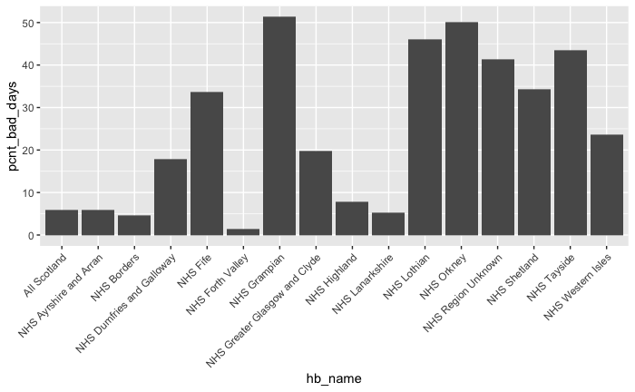

```r
weekly_admissions_spec %>%
  filter(speciality=="All") %>%
  filter(admission_type =="Emergency") %>%
  #filter(speciality=="Accident & Emergency") %>%
  #filter(year == 2020) %>%
  #filter(iswinter) %>%
  group_by(hb_name) %>%
  summarise(count_bad_days = sum(above_thresh),
            count_days = n()*7,
            pcnt_bad_days = 100*(sum(above_thresh)/(n()*7)),
            mean_percentvar =mean(percent_variation)) %>%
  ggplot() +
  aes(x=hb_name, y=pcnt_bad_days) +
  geom_col() +
  theme(axis.text.x = element_text(angle = 45, hjust = 1))
```

quick look at winter v summer

```r
weekly_admissions_spec %>%
  filter(speciality=="Accident & Emergency") %>%
  filter(admission_type =="All") %>%
  group_by(iswinter, year) %>%
  summarise(pcnt_bad_days = sum(above_thresh)/n()*7, mean_percentvar =mean(percent_variation))
```

| iswinter | year | pcnt_bad_days | mean_percentvar |
| --- | --- | --- | --- |
| FALSE | 2020 | 21.43750 | 1.346154 |
| FALSE | 2021 | 28.09633 | 17.627523 |
| FALSE | 2022 | 19.07027 | -13.135676 |
| TRUE | 2020 | 28.33175 | 43.717536 |
| TRUE | 2021 | 24.97573 | 14.352427 |
| TRUE | 2022 | 21.13725 | 2.098693 |

no obvious big discrepancy in winter admissions for this parameter winters of 2020 and 2022 are ‘worse’ than summers, percentages are small and maybe not significant?

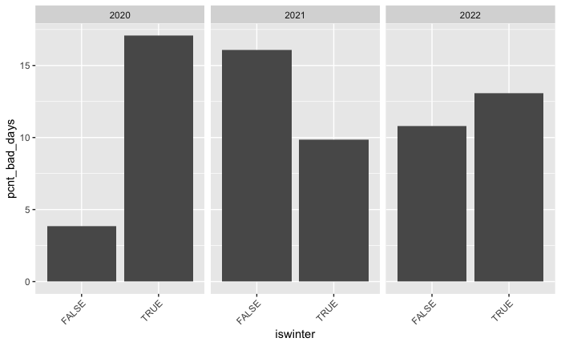

```r
weekly_admissions_spec %>%
  filter(speciality=="All") %>%
  filter(admission_type =="All") %>%
  group_by(iswinter, year) %>%
  summarise(count_bad_days = sum(above_thresh),
            count_days = n()*7,
            pcnt_bad_days = 100*(sum(above_thresh)/(n()*7)),
            mean_percentvar =mean(percent_variation)) %>%
  ggplot() +
  aes(x=iswinter, y=pcnt_bad_days) +
  geom_col() +
  theme(axis.text.x = element_text(angle = 45, hjust = 1)) +
  facet_grid(~year)
```

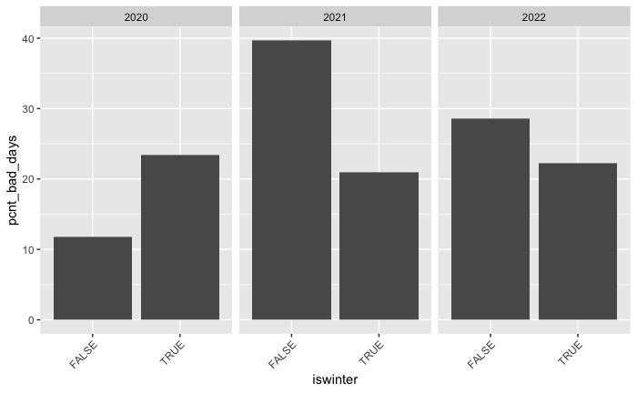

```r
weekly_admissions_spec %>%
  filter(speciality=="All") %>%
  filter(admission_type =="Emergency") %>%
  group_by(iswinter, year) %>%
  summarise(count_bad_days = sum(above_thresh),
            count_days = n()*7,
            pcnt_bad_days = 100*(sum(above_thresh)/(n()*7)),
            mean_percentvar =mean(percent_variation)) %>%
  ggplot() +
  aes(x=iswinter, y=pcnt_bad_days) +
  geom_col() +
  theme(axis.text.x = element_text(angle = 45, hjust = 1)) +
  facet_grid(~year)
```

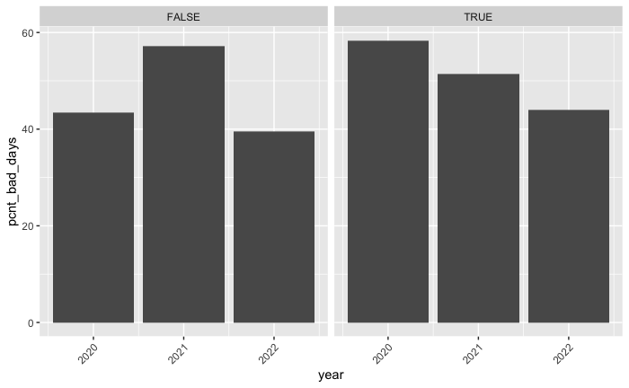

```r
weekly_admissions_spec %>%
  filter(speciality=="Accident & Emergency") %>%
  filter(admission_type =="Emergency") %>%
  group_by(iswinter, year) %>%
  summarise(count_bad_days = sum(above_thresh),
            count_days = n()*7,
            pcnt_bad_days = 100*(sum(above_thresh)/(n()*7)),
            mean_percentvar =mean(percent_variation)) %>%
  ggplot() +
  aes(x=year, y=pcnt_bad_days) +
  geom_col() +
  theme(axis.text.x = element_text(angle = 45, hjust = 1)) +
  facet_grid(~iswinter)
```